# Machine Learning Project

mapleset

October 21, 2015

## Synopsis

Using wearable fitness trackers, enthusiasts and athletes can collect data about their personal fitness activity. They use the measurements to improve their health and find patterns in their activity. They are typically interested in tracking how much of a particular activity they do, but not in whether it is done properly or improperly. In this project, our goal is to use data from accelerometers on the belt, forearm, arm, and dumbell of 6 participants to predict the manner in which they did the exercise. This is the ‘classe’ variable. The subjects were asked to perform barbell lifts correctly and incorrectly in 5 different ways. More information is available from the website here: http://groupware.les.inf.puc-rio.br/har (see the section on the Weight Lifting Exercise Dataset).

```r
library(caret)
library(randomForest)
```

## Data Processing

Load the training and test sets.

```r
training <- read.csv("pml-training.csv")
testing <- read.csv("pml-testing.csv")
```

Partition the training data into 2 parts, a 60% for a training set and 40% for a cross-validation set.

```r
inTrain <- createDataPartition(y = training$classe, p=0.60)[[1]]
trainingSet_ <- training[inTrain,]
cvSet <- training[-inTrain,]
dim(trainingSet_)
```

```
## [1] 11776   160
```

```r
dim(cvSet)
```

```
## [1] 7846  160
```

We now want to determine which variables of the training set are of little value or have a high correlation to other variables and eliminate these columns from the training and cross-validation sets. We will eliminate columns with Near Zero Variation, as well as columns that are mostly NA. We also will use a Correlation Matrix to find columns to remove in order to reduce pair-wise correlations.

```r
# eliminate the first 7 columns as they provide no valuable information for prediction
cols_ <- c(8:160)

# check for near-zero-variability
nzvCols <- nearZeroVar(trainingSet_)
# keep only columns not in the NZV set
cols__ <- cols_[! cols_ %in% nzvCols]

# find columns that are mostly NA
manyNACols <- (colSums(is.na(trainingSet_)) > 1000) # if the column contains > 1000 NA's
manyNACols_names <- names(manyNACols[manyNACols==1])
manyNAColIndexes <- which(names(trainingSet_) %in% manyNACols_names)

# keep only columns not in the 'mostly NA' set
cols <- cols__[! cols__ %in% manyNAColIndexes]

# create subsets that don't have NZV or mostly NA values
trainingSet__ <- trainingSet_[,cols]

# find the index for the classe column
class_col <- which(colnames(trainingSet__)=="classe")

# create a correlation matrix to reduce/eliminate overfitting
M <- cor(trainingSet__[,-class_col])
diag(M) <- 0

# findCorrelation searches through the correlation matrix and returns a vector of integers corresponding to columns to remove in order for us to reduce pair-wise correlations.
reduceCols <- findCorrelation(M, cutoff = .9)
trainingSet <- trainingSet__[,-reduceCols]
class_col <- which(colnames(trainingSet)=="classe") # recalc after reduction
```

## Model Building

After pre-processing the data, we now need to build a prediction model. The random forest algorithm was chosen because it builds a number of trees with bootstrapped sampling and uses the average of the predictions to form the final prediction. Because, internally, it uses an approximate 60/40 split of the dataset for training and test (OOB/Out of Bag) data, it eliminates the need to supply separate training and test data data for model building.

```r
set.seed(3433)
modelFit <- randomForest(classe ~ .,data = trainingSet,importance = TRUE,ntrees = 100)
```

```r
print(modelFit)
```

```
##
## Call:
##  randomForest(formula = classe ~ ., data = trainingSet, importance = TRUE,      ntrees = 100)
##                Type of random forest: classification
##                      Number of trees: 500
## No. of variables tried at each split: 6
##
##         OOB estimate of  error rate: 0.78%
## Confusion matrix:
##      A    B    C    D    E  class.error
## A 3346    2    0    0    0 0.0005973716
## B   19 2248   12    0    0 0.0136024572
## C    0   19 2032    3    0 0.0107108082
## D    0    0   26 1903    1 0.0139896373
## E    0    1    3    6 2155 0.0046189376
```

```r
#plot(modelFit)
```

Plot the importance of variables (MeanDecreaseAccuracy vs variable name). We see that ‘yaw_belt’ is the most important for determining accuracy.

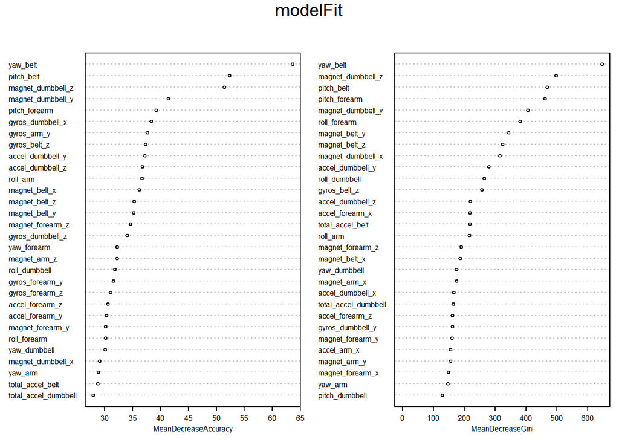

```r
varImpPlot(modelFit,cex=.5)
```

## Cross Validation

We will now test the accuracy of the model using the cross-validation set. This is important to ensure we don’t have overfitting ot the model.

```r
cvSetPC <- predict(modelFit, cvSet)
table(cvSet$classe, cvSetPC)
```

```
##    cvSetPC
##        A    B    C    D    E
##   A 2229    2    0    0    1
##   B   17 1498    3    0    0
##   C    0    8 1356    4    0
##   D    0    0   13 1270    3
##   E    0    0    0    5 1437
```

By viewing the confusion matrix, we can see a number of statistics about the model’s prediction value on the cross-validation data set. It is showing us the model’s accuracy for the CV set as 99+ % .

```r
confusionMatrix(cvSet$classe, cvSetPC)
```

```
## Confusion Matrix and Statistics
##
##           Reference
## Prediction    A    B    C    D    E
##          A 2229    2    0    0    1
##          B   17 1498    3    0    0
##          C    0    8 1356    4    0
##          D    0    0   13 1270    3
##          E    0    0    0    5 1437
##
## Overall Statistics
##
##                Accuracy : 0.9929
##                  95% CI : (0.9907, 0.9946)
##     No Information Rate : 0.2863
##     P-Value [Acc > NIR] : < 2.2e-16
##
##                   Kappa : 0.991
##  Mcnemar's Test P-Value : NA
##
## Statistics by Class:
##
##                      Class: A Class: B Class: C Class: D Class: E
## Sensitivity            0.9924   0.9934   0.9883   0.9930   0.9972
## Specificity            0.9995   0.9968   0.9981   0.9976   0.9992
## Pos Pred Value         0.9987   0.9868   0.9912   0.9876   0.9965
## Neg Pred Value         0.9970   0.9984   0.9975   0.9986   0.9994
## Prevalence             0.2863   0.1922   0.1749   0.1630   0.1837
## Detection Rate         0.2841   0.1909   0.1728   0.1619   0.1832
## Detection Prevalence   0.2845   0.1935   0.1744   0.1639   0.1838
## Balanced Accuracy      0.9959   0.9951   0.9932   0.9953   0.9982
```

## Prediction

And finally, predict the ‘classe’ of each of the 20 rows of the testing data. This resulted in a 20 out of 20 accuracy when the data was submitted for automated testing.

```r
testPC <- predict(modelFit, testing)
summary(testPC)
```

```
## A B C D E
## 7 8 1 1 3
```

```r
testPC
```

```
##  1  2  3  4  5  6  7  8  9 10 11 12 13 14 15 16 17 18 19 20
##  B  A  B  A  A  E  D  B  A  A  B  C  B  A  E  E  A  B  B  B
## Levels: A B C D E
```

Define a function to write the files needed for submission

```r
pml_write_files = function(x)
{
  n = length(x)
  for(i in 1:n)
  {
    filename = paste0("problem_id_",i,".txt")
    write.table(x[i],file=filename,quote=FALSE,row.names=FALSE,col.names=FALSE)
  }
}
```

Write out the answers to files for submission.

```r
#answers <- as.vector(testPC)
#setwd("Answers")
#pml_write_files(testPC)
#setwd("..")
```